# Reproducible Research: Peer Assessment 1

## Assignment Info

- Filename: PA1_template.Rmd
- Name: Walter Yu
- Date: July 2020

### Introduction

This markdown file is an analysis and visualization of UCI human activity recognition dataset. Source data for this assignment is an aggregated dataset from the original available [here](https://archive.ics.uci.edu/ml/datasets/human+activity+recognition+using+smartphones).

This assignment is completed for the JHU Coursera Data Science Program, which is a 10 course certification. More info about this program is available [here](https://www.coursera.org/specializations/jhu-data-science).

### HTML File/Template

The HTML file for this assignment was generated with [R Studio Cloud](https://rstudio.cloud) due to dplyr package installation errors on my local machine; as a result, file was run and report rendered there instead.

This markdown project template is based on a fork of the course assignment Github repo available [here](https://rstudio.cloud).

### Notes

1. All code included to show data import and plot
2. Full dataset was imported, then subset for plot
3. Plotting systems used per assignment instructions

## Loading and preprocessing the data

### Part 1: Import data per assignment instructions

Processing Steps: * Loaded data with read.csv function per instructions * File was unzipped, then read into program

### Part 2: Remove null values

Processing Steps: * Used na.omit function to remove null values * Assigned results to a new variable

```r
# part 1: import data per assignment instructions
# source: assignment instructions
activity <- read.csv("activity.csv")

# review dataset
# https://www.statmethods.net/stats/descriptives.html
head(activity)
```

```
##   steps       date interval
## 1    NA 2012-10-01        0
## 2    NA 2012-10-01        5
## 3    NA 2012-10-01       10
## 4    NA 2012-10-01       15
## 5    NA 2012-10-01       20
## 6    NA 2012-10-01       25
```

```r
names(activity)
```

```
## [1] "steps"    "date"     "interval"
```

```r
summary(activity)
```

```
##      steps            date              interval
##  Min.   :  0.00   Length:17568       Min.   :   0.0
##  1st Qu.:  0.00   Class :character   1st Qu.: 588.8
##  Median :  0.00   Mode  :character   Median :1177.5
##  Mean   : 37.38                      Mean   :1177.5
##  3rd Qu.: 12.00                      3rd Qu.:1766.2
##  Max.   :806.00                      Max.   :2355.0
##  NA's   :2304
```

```r
# part 2: remove null values
# source: https://www.statmethods.net/input/missingdata.html
activity_omit <- na.omit(activity)

# verify results
# https://www.statmethods.net/stats/descriptives.html
head(activity_omit)
```

```
##     steps       date interval
## 289     0 2012-10-02        0
## 290     0 2012-10-02        5
## 291     0 2012-10-02       10
## 292     0 2012-10-02       15
## 293     0 2012-10-02       20
## 294     0 2012-10-02       25
```

```r
names(activity_omit)
```

```
## [1] "steps"    "date"     "interval"
```

```r
summary(activity_omit)
```

```
##      steps            date              interval
##  Min.   :  0.00   Length:15264       Min.   :   0.0
##  1st Qu.:  0.00   Class :character   1st Qu.: 588.8
##  Median :  0.00   Mode  :character   Median :1177.5
##  Mean   : 37.38                      Mean   :1177.5
##  3rd Qu.: 12.00                      3rd Qu.:1766.2
##  Max.   :806.00                      Max.   :2355.0
```

## What is mean total number of steps taken per day?

### Part 1: Calculate sum, then create histogram

Processing Steps: * Used aggreage function to calculate total steps/day * Assigned results to a new variable

Analysis: * Used head, names and summary functions to review the data * Verified that aggregate returned total steps per day

Plot: * Created histogram for steps/day; axis adjusted to fit data * Applied bins to visualize the data effectively

### Part 2: Calculate mean/median by date

Processing Steps: * Used aggreage function to calculate mean/median steps/day * Assigned results to a new variable

Analysis: * Used head, names and summary functions to review the data * Verified that aggregate returned mean/median steps per day * Median steps/day = 0 due to large number of zero step values

```r
# part 1: calculate sum, then create histogram
# aggregate by date, then apply calculations
# source: https://www.statmethods.net/management/aggregate.html
steps_sum <- aggregate(steps ~ date, activity_omit, sum)

# verify results
# https://www.statmethods.net/stats/descriptives.html
head(steps_sum)
```

```
##         date steps
## 1 2012-10-02   126
## 2 2012-10-03 11352
## 3 2012-10-04 12116
## 4 2012-10-05 13294
## 5 2012-10-06 15420
## 6 2012-10-07 11015
```

```r
names(steps_sum)
```

```
## [1] "date"  "steps"
```

```r
summary(steps_sum)
```

```
##      date               steps
##  Length:53          Min.   :   41
##  Class :character   1st Qu.: 8841
##  Mode  :character   Median :10765
##                     Mean   :10766
##                     3rd Qu.:13294
##                     Max.   :21194
```

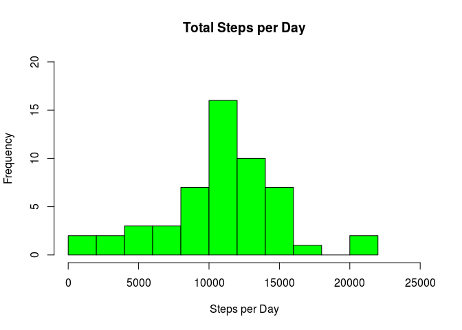

```r
# create histogram plot; adjust axis and bins
# source: https://www.statmethods.net/graphs/density.html
hist(steps_sum$steps, col="green",
     breaks=10, main="Total Steps per Day",
     xlab="Steps per Day", ylim=c(0,20), xlim=c(0,25000))
```

```r
# part 2: calculate mean/median by date
# aggregate by date, then apply calculations
# source: https://www.statmethods.net/management/aggregate.html
steps_mean <- aggregate(steps ~ date, activity_omit, mean)

# verify results
# https://www.statmethods.net/stats/descriptives.html
head(steps_mean)
```

```
##         date    steps
## 1 2012-10-02  0.43750
## 2 2012-10-03 39.41667
## 3 2012-10-04 42.06944
## 4 2012-10-05 46.15972
## 5 2012-10-06 53.54167
## 6 2012-10-07 38.24653
```

```r
names(steps_mean)
```

```
## [1] "date"  "steps"
```

```r
summary(steps_mean)
```

```
##      date               steps
##  Length:53          Min.   : 0.1424
##  Class :character   1st Qu.:30.6979
##  Mode  :character   Median :37.3785
##                     Mean   :37.3826
##                     3rd Qu.:46.1597
##                     Max.   :73.5903
```

```r
# aggregate by date, then apply calculations
# source: https://www.statmethods.net/management/aggregate.html
steps_median <- aggregate(steps ~ date, activity_omit, median)

# verify results
# https://www.statmethods.net/stats/descriptives.html
head(steps_median)
```

```
##         date steps
## 1 2012-10-02     0
## 2 2012-10-03     0
## 3 2012-10-04     0
## 4 2012-10-05     0
## 5 2012-10-06     0
## 6 2012-10-07     0
```

```r
names(steps_median)
```

```
## [1] "date"  "steps"
```

```r
summary(steps_median)
```

```
##      date               steps
##  Length:53          Min.   :0
##  Class :character   1st Qu.:0
##  Mode  :character   Median :0
##                     Mean   :0
##                     3rd Qu.:0
##                     Max.   :0
```

## What is the average daily activity pattern?

### Part 1: Group by interval, calculate mean and plot time series

Processing Steps: * Used dplyr/group_by to calculate mean steps/interval * Assigned results to a new variable

Analysis: * Used head, names and summary functions to review the data * Verified that mean of steps/interval differ from steps/day

Plot: * Created time series plot; add axis labels and line color

Notes: * Assumed instructions were for steps/interval across ALL DAYS * So, mean was calculated per interval for entire data set * NOT group by interval, then calculate mean by date

### Part 2: Find interval with maximum steps across all days

Processing Steps: * Used which function to subset for maximum steps/interval * Assigned results to a new variable

Analysis: * Interval 835 had the maximum steps/interval.

```r
# part 1: group by interval, calculate mean and plot time series
# group by interval, then calculate mean steps for each group
# source: https://datacarpentry.org/R-genomics/04-dplyr.html
install.packages("dplyr")
library(dplyr)
steps_avg_interval <- activity_omit %>%
    group_by(interval) %>%
    summarize(steps_avg = mean(steps))
# verify results
# https://www.statmethods.net/stats/descriptives.html
head(steps_avg_interval)
```

```
## # A tibble: 6 x 2
##   interval steps_avg
##      <int>     <dbl>
## 1        0    1.72
## 2        5    0.340
## 3       10    0.132
## 4       15    0.151
## 5       20    0.0755
## 6       25    2.09
```

```r
names(steps_avg_interval)
```

```
## [1] "interval"  "steps_avg"
```

```r
summary(steps_avg_interval)
```

```
##     interval        steps_avg
##  Min.   :   0.0   Min.   :  0.000
##  1st Qu.: 588.8   1st Qu.:  2.486
##  Median :1177.5   Median : 34.113
##  Mean   :1177.5   Mean   : 37.383
##  3rd Qu.:1766.2   3rd Qu.: 52.835
##  Max.   :2355.0   Max.   :206.170
```

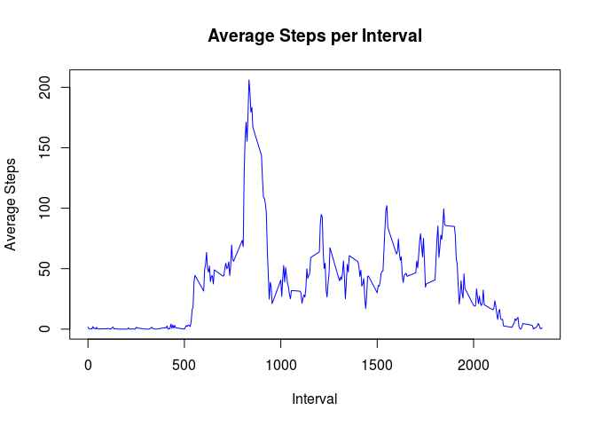

```r
# create time series plot; use date list and sum of steps
# source: https://www.datamentor.io/r-programming/plot-function/
plot(steps_avg_interval,
     main="Average Steps per Interval",
     xlab="Interval",
     ylab="Average Steps",
     col="blue",
     type="l")
```

```r
# part 2: find interval with maximum steps across all days
# source: https://stackoverflow.com/questions/19449615/how-to-extract-the-row-with-min-or-max-values
max_interval <- steps_avg_interval[which.max(steps_avg_interval$steps_avg),]

# return row with max interval
print("Subset for maximum interval and return result.")
```

```
## [1] "Subset for maximum interval and return result."
```

```r
max_interval
```

```
## # A tibble: 1 x 2
##   interval steps_avg
##      <int>     <dbl>
## 1      835      206.
```

## Imputing missing values

### Part 1: Return count of rows with null values

Processing Steps: * Used is.na function to subset for records with null * Assigned results to a new variable

### Part 2-3: Create new dataset with imputed null values

Notes: * Numerous attempts were made with dplyr/group_by which failed * Code left to document previous attempts * As a result, simputation package was used to yield result

### Part 4: calculate sum, then create histogram

Processing Steps: * Used aggreage function to calculate total steps/day * Assigned results to a new variable

```r
# part 1: return count of rows with null values
# https://stackoverflow.com/questions/7980622/subset-of-rows-containing-na-missing-values-in-a-chosen-column-of-a-data-frame
activity_na <- activity[is.na(activity),]

# return row with max interval
print("Subset for records with null values and return count.")
```

```
## [1] "Subset for records with null values and return count."
```

```r
nrow(activity_na)
```

```
## [1] 2304
```

```r
# part 2-3: create new dataset with imputed null values
# replace null with mean value by date
# source: https://datascience.stackexchange.com/questions/14065/imputing-missing-values-by-mean-by-id-column-in-r
# https://stackoverflow.com/questions/27207162/fill-in-na-based-on-the-last-non-na-value-for-each-group-in-r
# library(zoo)
# activity_imp %>%
#     group_by(date) %>%
#     mutate(step=zoo::na.locf(steps))
#     transmute(steps=na.locf(steps, na.rm=FALSE))
#     mutate(steps=ifelse(is.na(steps),mean(steps, na.rm=TRUE),steps))

# source: https://stackoverflow.com/questions/21714867/replace-na-in-a-dplyr-chain
# library(data.table)
# names(activity_imp)
# activity_imp[, steps := ifelse(
#   is.na(steps),mean(steps,na.rm=TRUE), steps), by=date]

# source: https://github.com/decisionpatterns/tidyimpute/issues/5
# activity_imp %>%
#   group_by(date) %>%
#   group_modify(~ impute_median(.x, steps)) %>%
#   ungroup()

# source: https://tidyr.tidyverse.org/reference/fill.html
# install.packages("tidyverse")
# library(tidyverse)
# activity_imp %>%
#   group_by(date) %>%
#   fill(steps, .direction="downup") %>%
#   ungroup()

# source: https://cran.r-project.org/web/packages/simputation/vignettes/intro.html
install.packages('simputation')
library(simputation)
activity_imp <- impute_lm(activity, steps ~ interval)

# verify results
# https://www.statmethods.net/stats/descriptives.html
nrow(activity_imp)
```

```
## [1] 17568
```

```r
head(activity_imp)
```

```
##      steps       date interval
## 1 29.55387 2012-10-01        0
## 2 29.58711 2012-10-01        5
## 3 29.62036 2012-10-01       10
## 4 29.65360 2012-10-01       15
## 5 29.68684 2012-10-01       20
## 6 29.72009 2012-10-01       25
```

```r
names(activity_imp)
```

```
## [1] "steps"    "date"     "interval"
```

```r
# compare raw and imputed data
# https://www.statmethods.net/stats/descriptives.html
summary(activity)
```

```
##      steps            date              interval
##  Min.   :  0.00   Length:17568       Min.   :   0.0
##  1st Qu.:  0.00   Class :character   1st Qu.: 588.8
##  Median :  0.00   Mode  :character   Median :1177.5
##  Mean   : 37.38                      Mean   :1177.5
##  3rd Qu.: 12.00                      3rd Qu.:1766.2
##  Max.   :806.00                      Max.   :2355.0
##  NA's   :2304
```

```r
summary(activity_imp)
```

```
##      steps            date              interval
##  Min.   :  0.00   Length:17568       Min.   :   0.0
##  1st Qu.:  0.00   Class :character   1st Qu.: 588.8
##  Median :  0.00   Mode  :character   Median :1177.5
##  Mean   : 37.38                      Mean   :1177.5
##  3rd Qu.: 34.37                      3rd Qu.:1766.2
##  Max.   :806.00                      Max.   :2355.0
```

```r
# part 4: calculate sum, then create histogram
# aggregate by date, then apply calculations
# source: https://www.statmethods.net/management/aggregate.html
steps_sum_imp <- aggregate(steps ~ date, activity_imp, sum)
summary(steps_sum_imp)
```

```
##      date               steps
##  Length:61          Min.   :   41
##  Class :character   1st Qu.: 9819
##  Mode  :character   Median :10766
##                     Mean   :10766
##                     3rd Qu.:12811
##                     Max.   :21194
```

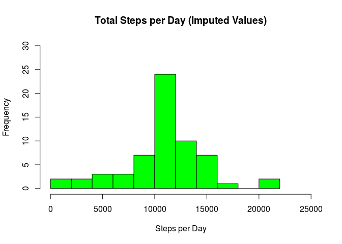

```r
# create histogram plot
# source: https://www.statmethods.net/graphs/density.html
hist(steps_sum_imp$steps, col="green",
     breaks=10, main="Total Steps per Day (Imputed Values)",
     xlab="Steps per Day", ylim=c(0,30), xlim=c(0,25000))
```

```r
# aggregate by date, then apply calculations
# source: https://www.statmethods.net/management/aggregate.html
steps_mean_imp <- aggregate(steps ~ date, activity_imp, mean)
summary(steps_mean)
```

```
##      date               steps
##  Length:53          Min.   : 0.1424
##  Class :character   1st Qu.:30.6979
##  Mode  :character   Median :37.3785
##                     Mean   :37.3826
##                     3rd Qu.:46.1597
##                     Max.   :73.5903
```

```r
summary(steps_mean_imp)
```

```
##      date               steps
##  Length:61          Min.   : 0.1424
##  Class :character   1st Qu.:34.0938
##  Mode  :character   Median :37.3826
##                     Mean   :37.3826
##                     3rd Qu.:44.4826
##                     Max.   :73.5903
```

```r
# aggregate by date, then apply calculations
# source: https://www.statmethods.net/management/aggregate.html
steps_median_imp <- aggregate(steps ~ date, activity_imp, median)
summary(steps_median)
```

```
##      date               steps
##  Length:53          Min.   :0
##  Class :character   1st Qu.:0
##  Mode  :character   Median :0
##                     Mean   :0
##                     3rd Qu.:0
##                     Max.   :0
```

```r
summary(steps_median_imp)
```

```
##      date               steps
##  Length:61          Min.   : 0.000
##  Class :character   1st Qu.: 0.000
##  Mode  :character   Median : 0.000
##                     Mean   : 4.903
##                     3rd Qu.: 0.000
##                     Max.   :37.383
```

## Are there differences in activity patterns between weekdays and weekends?

Processing Steps: * Created weekday/weekend factor with ifelse logic * Used weekdays function to create weekday/weekend values

### Part 2: Create time series facet plot

Plot: * Created time series facet plot; add line color

```r
# part 1: create weekday/weekend factor within dataset

# first, create weekday/weekend categorical variable
# source: https://sphweb.bumc.bu.edu/otlt/MPH-Modules/BS/R/R-Manual/R-Manual4.html
activity_imp$wday_type <- ifelse(
    weekdays(as.Date(activity_imp$date)) == "Saturday" |
    weekdays(as.Date(activity_imp$date)) == "Sunday",
    "Weekend",
    "Weekday"
)

# verify results
# https://www.statmethods.net/stats/descriptives.html
nrow(activity_imp)
```

```
## [1] 17568
```

```r
head(activity_imp)
```

```
##      steps       date interval wday_type
## 1 29.55387 2012-10-01        0   Weekday
## 2 29.58711 2012-10-01        5   Weekday
## 3 29.62036 2012-10-01       10   Weekday
## 4 29.65360 2012-10-01       15   Weekday
## 5 29.68684 2012-10-01       20   Weekday
## 6 29.72009 2012-10-01       25   Weekday
```

```r
names(activity_imp)
```

```
## [1] "steps"     "date"      "interval"  "wday_type"
```

```r
summary(activity_imp)
```

```
##      steps            date              interval       wday_type
##  Min.   :  0.00   Length:17568       Min.   :   0.0   Length:17568
##  1st Qu.:  0.00   Class :character   1st Qu.: 588.8   Class :character
##  Median :  0.00   Mode  :character   Median :1177.5   Mode  :character
##  Mean   : 37.38                      Mean   :1177.5
##  3rd Qu.: 34.37                      3rd Qu.:1766.2
##  Max.   :806.00                      Max.   :2355.0
```

```r
unique(activity_imp$wday_type)
```

```
## [1] "Weekday" "Weekend"
```

```r
# group by interval, then calculate mean steps for each group
# source: https://datacarpentry.org/R-genomics/04-dplyr.html
# install.packages("dplyr")
# library(dplyr)
steps_avg_wday <- activity_imp %>%
    group_by(steps, interval, wday_type) %>%
    summarize(steps_avg = mean(steps))
# verify results
# https://www.statmethods.net/stats/descriptives.html
head(steps_avg_wday)
```

```
## # A tibble: 6 x 4
## # Groups:   steps, interval [3]
##   steps interval wday_type steps_avg
##   <dbl>    <int> <chr>         <dbl>
## 1     0        0 Weekday           0
## 2     0        0 Weekend           0
## 3     0        5 Weekday           0
## 4     0        5 Weekend           0
## 5     0       10 Weekday           0
## 6     0       10 Weekend           0
```

```r
names(steps_avg_wday)
```

```
## [1] "steps"     "interval"  "wday_type" "steps_avg"
```

```r
summary(steps_avg_wday)
```

```
##      steps           interval     wday_type           steps_avg
##  Min.   :  0.00   Min.   :   0   Length:5235        Min.   :  0.00
##  1st Qu.: 19.00   1st Qu.: 830   Class :character   1st Qu.: 19.00
##  Median : 41.62   Median :1305   Mode  :character   Median : 41.62
##  Mean   :111.60   Mean   :1290                      Mean   :111.60
##  3rd Qu.:107.50   3rd Qu.:1800                      3rd Qu.:107.50
##  Max.   :806.00   Max.   :2355                      Max.   :806.00
```

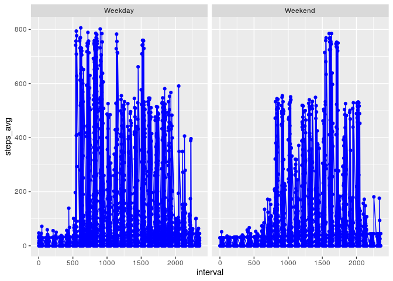

```r
# part 2: create time series facet plot
# source: http://zevross.com/blog/2019/04/02/easy-multi-panel-plots-in-r-using-facet_wrap-and-facet_grid-from-ggplot2/
install.packages("ggplot2")
library(ggplot2)
ggplot(data=steps_avg_wday, aes(interval, steps_avg)) +
    geom_line(color="blue") +
    geom_point(color="blue") +
    facet_wrap(~ wday_type)
```